# ggplot homework

```r
library(tidyverse)
library(ggplot2)
library(janitor)
library(CodeClanData)
```

1. Take the data in the dataset qb_revenue_breakdown and make a stacked bar chart showing the sources of revenue across the two years in the dataset

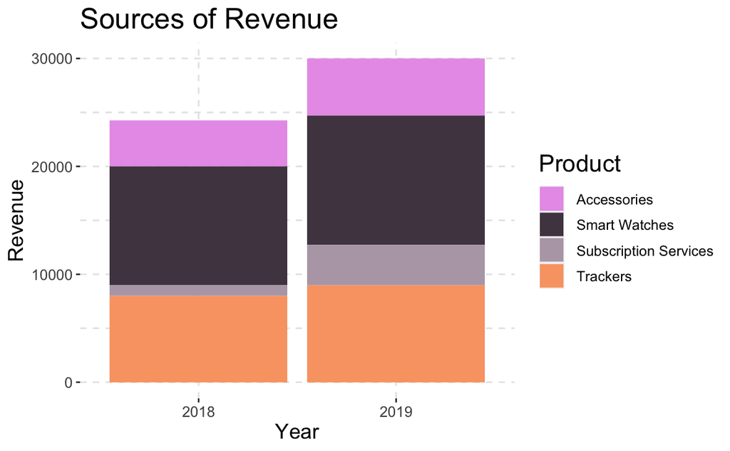

```r
qb_revenue_breakdown <- clean_names(qb_revenue_breakdown)

qb_device_theme <- function() {
  theme(
    panel.background = element_rect(fill = "white"),
    panel.grid.major.x = element_line(colour = "grey90", linetype = 2, size = 0.5),
    panel.grid.major.y =  element_line(colour = "grey90", linetype = 2, size = 0.5),
    panel.grid.minor.y = element_line(colour = "grey90", linetype = 2, size = 0.5),
    axis.text = element_text(size = 10),
    axis.title = element_text(size = 14),
    title = element_text(size = 16),
    text = element_text(size = 12)
  )
}

ggplot(qb_revenue_breakdown) +
  geom_bar(aes(x = year, y = revenue, fill = product),
           stat = "identity") +
  labs(x = "Year",
       y = "Revenue",
       title = "Sources of Revenue",
       fill = "Product") +
  scale_fill_manual(values = col_scheme <- c("#E89FE9", "#50434F", "#B6A7B5", "#F9A472", "#BD7040")) +
  qb_device_theme()
```

2. Make a line chart showing monthly sales of the “flagship product” - the ‘KwikBit Unit 1’ - over the last year. This data is inside qb_monthly_sales, but you will need to use filter() or subset() (base R).

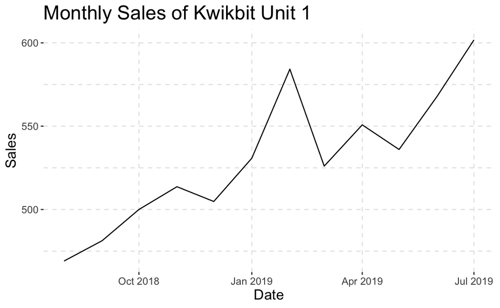

```r
qb_monthly_sales <- clean_names(qb_monthly_sales)

flagship_monthly <- qb_monthly_sales %>%
  filter(cashflow == "Kwikbit Unit 1 Sales")

ggplot(flagship_monthly) +
  geom_line(aes(x = date,
                y = amount)) +
  labs(x = "Date",
       y = "Sales",
       title = "Monthly Sales of Kwikbit Unit 1") +
  scale_fill_manual(
    values = col_scheme <- c("#E89FE9", "#50434F", "#B6A7B5", "#F9A472", "#BD7040")) +
  qb_device_theme()
```

3. Make a line chart showing monthly revenue and costs over the last year. This data is also in qb_monthly_sales

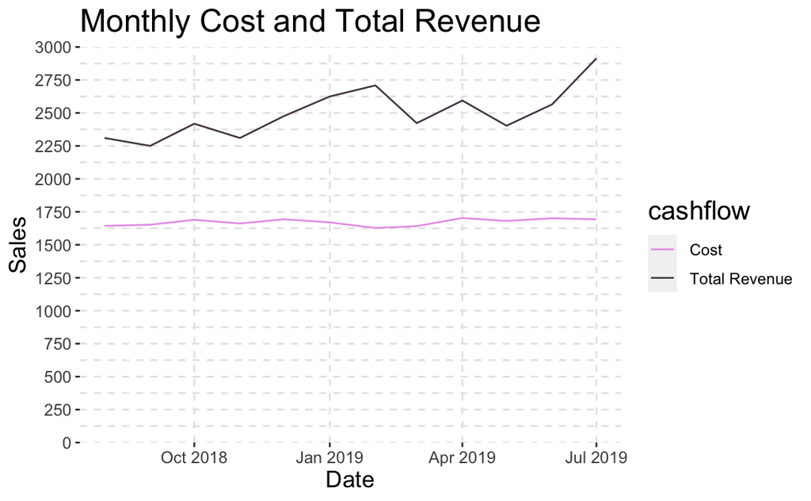

```r
revenue_and_costs <- qb_monthly_sales %>%
  filter(cashflow != "Kwikbit Unit 1 Sales")

ggplot(revenue_and_costs) +
  geom_line(aes(x = date,
                y = amount,
                colour = cashflow)) +
  labs(x = "Date",
       y = "Sales",
       title = "Monthly Cost and Total Revenue") +
  scale_y_continuous(expand = c(0,0),
                     limits = c(0, 3000),
                     breaks = seq(0, 3000, 250)) +
  scale_colour_manual(values = col_scheme <- c("#E89FE9", "#50434F", "#B6A7B5", "#F9A472", "#BD7040")) +
  qb_device_theme()
```

4. Show annual sales of personal fitness trackers over the last 5 years broken down by company as a ribbon plot (use geom_area). This data is in qb_competitors.

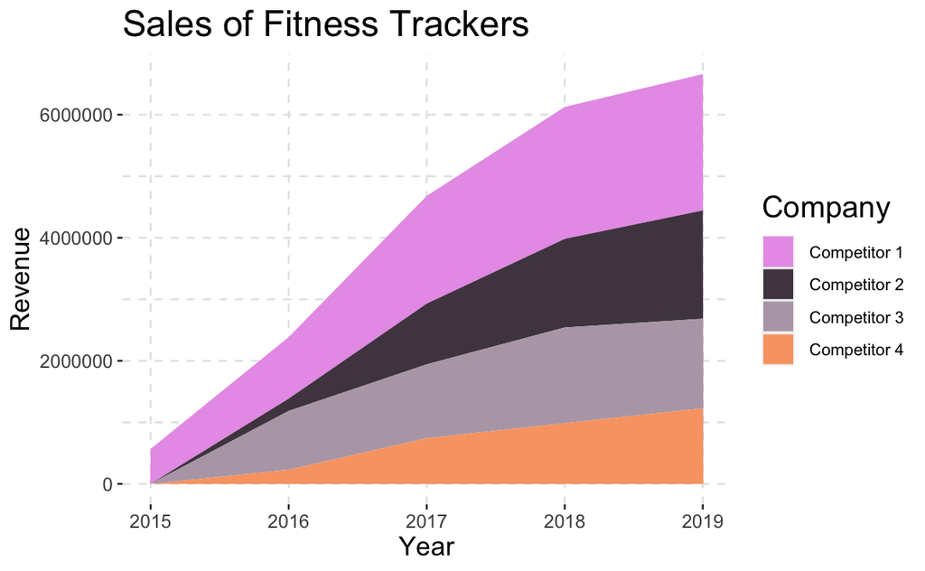

```r
qb_competitors <- clean_names(qb_competitors)

options(scipen = 10)
ggplot(qb_competitors) +
  geom_area(aes(x = year, y = revenue, fill = company)) +
  labs(x = "Year",
       y = "Revenue",
       title = "Sales of Fitness Trackers",
       fill = "Company") +
  scale_fill_manual(values = col_scheme <- c("#E89FE9", "#50434F", "#B6A7B5", "#F9A472", "#BD7040")) +
  qb_device_theme()
```

5. Now show the sales from the four competitors as a line graph. Include an extra layer that shows the data points used to make the lines.

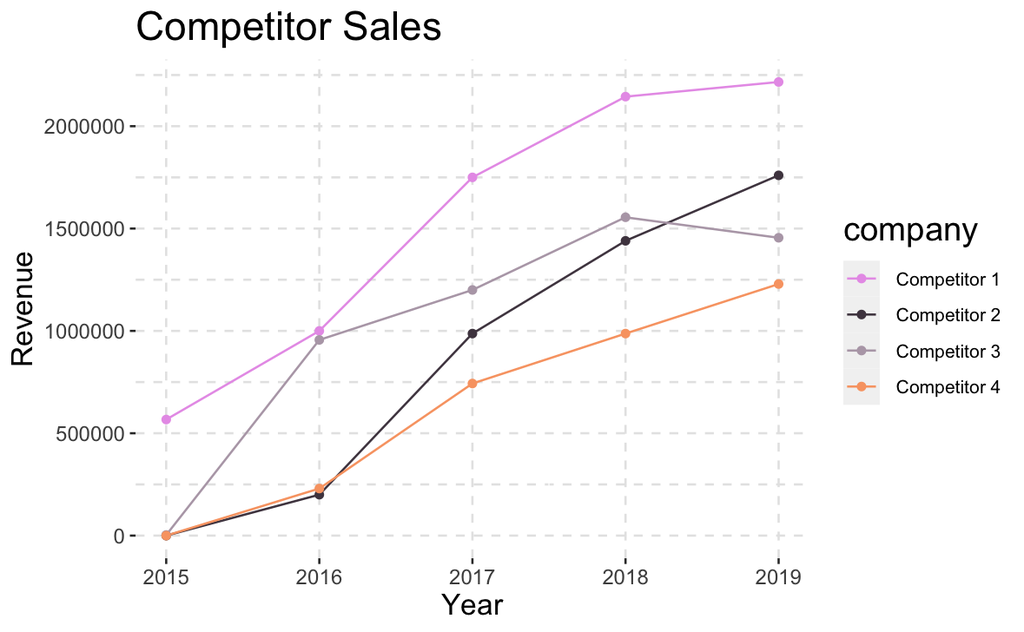

```r
ggplot(qb_competitors) +
  aes(x = year,
      y = revenue,
      colour = company) +
  geom_line() +
  geom_point() +
  labs(x = "Year",
       y = "Revenue",
       title = "Competitor Sales",
       fill = "Company") +
  scale_colour_manual(values = col_scheme <- c("#E89FE9", "#50434F", "#B6A7B5", "#F9A472", "#BD7040")) +
  qb_device_theme()
```

6. Now the company wants to compare the number of steps that their device counts vs. their competitors. Make a line graph of the number of steps throughout time, and use faceting to compare between companies and people. The data for this is in qb_device_data.

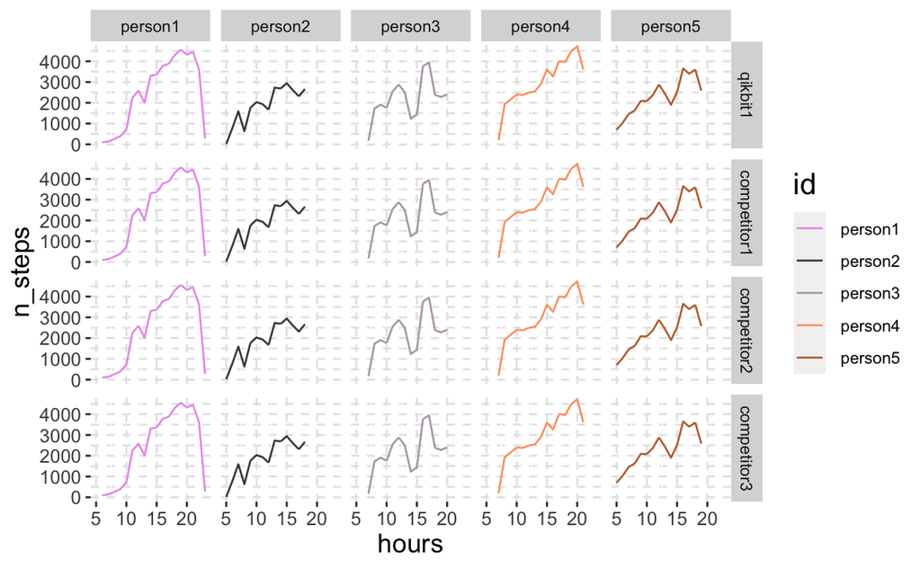

```r
filter_device <- qb_device_data %>%
  filter(counts != 0) %>%
  group_by(id, hours) %>%
  summarise(n_steps = sum(hours), device)
ggplot(filter_device) +
  aes(x = hours, y = n_steps, group = device, colour = id) +
  geom_line() +
  facet_grid(device ~ id) +
  scale_colour_manual(values = col_scheme <- c("#E89FE9", "#50434F", "#B6A7B5", "#F9A472", "#BD7040")) +
  qb_device_theme()
```

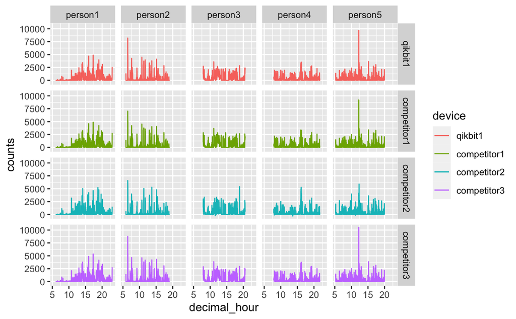

```r
qb_device_data %>%
  mutate(decimal_hour = hours + (mins / 60)) %>%
ggplot(aes(x = decimal_hour, y = counts)) +
  geom_line(aes(colour = device)) +
  facet_grid(device ~ id)
```

```r
?theme
```